- [X] Zbuduj las losowy przewidujący złośliwość nowotworu na danych biopsy.

```r
library(MASS)
library(randomForest)
data(biopsy)
biopsy <- na.omit(biopsy)
biopsy$ID <- NULL

rf<-randomForest(class~.,data=biopsy, importance = TRUE)
rf
```

```
##
## Call:
##  randomForest(formula = class ~ ., data = biopsy, importance = TRUE)
##                Type of random forest: classification
##                      Number of trees: 500
## No. of variables tried at each split: 3
##
##         OOB estimate of  error rate: 2.64%
## Confusion matrix:
##           benign malignant class.error
## benign       432        12  0.02702703
## malignant      6       233  0.02510460
```

-[X] Sprawdź, czy jego dokładność w walidacji krzyżowej przebije 96%, czyli tę którą osiągnęliśmy korzystając z modelu logistycznego.

```r
# imprementacja k-walidacji krzyżowej, dzielimy na k=20 cześci
k <- 20
k_podzial <- cut(1:nrow(biopsy), k, labels = F)
k_podzial <- sample(k_podzial)
error <- replicate(k, 0)
for(i in 1:k) {
  train <- which(k_podzial==i)
  y_acc <- biopsy[-train,'class']

  rf <- randomForest(class~., data=biopsy, subset=train) #liczbymy na k-tym podziale
  y_hat <- predict(rf, biopsy[-train,])

  error[i] <- mean(y_hat!=y_acc) # błąd
}
error
```

```
##  [1] 0.03549383 0.03235747 0.03697997 0.04160247 0.04160247 0.03389831
##  [7] 0.04160247 0.02773498 0.04006163 0.05555556 0.07241911 0.04776579
## [13] 0.04160247 0.04006163 0.04006163 0.06471495 0.05855162 0.04468413
## [19] 0.03235747 0.16512346
```

Estymowany błąd testowy znajdziesz w podstawowych informacjach dotyczących utworzonego modelu, które uzyskasz wpisując jego nazwę w konsolę.

[figure not shown]

```r
varImpPlot(rf)
```

Jest on opisany jako ‘OOB estimate of error rate’ - jest to tak zwany błąd out-of-bag, który przybliża błąd walidacji krzyżowej. Przedstaw istotność zmiennych na wykresie, wykorzystując funkcję varImpPlot lub bibliotekę ggplot2.

```r
#funkcja licząca błąd
computeOOBErrEst <- function (model)
{
  cm <- model$confusion
  cm <- cm[, -ncol(cm)]
  1 - sum(diag(cm)) / sum(cm)
}
computeOOBErrEst(rf)
```

```
## [1] 0
```

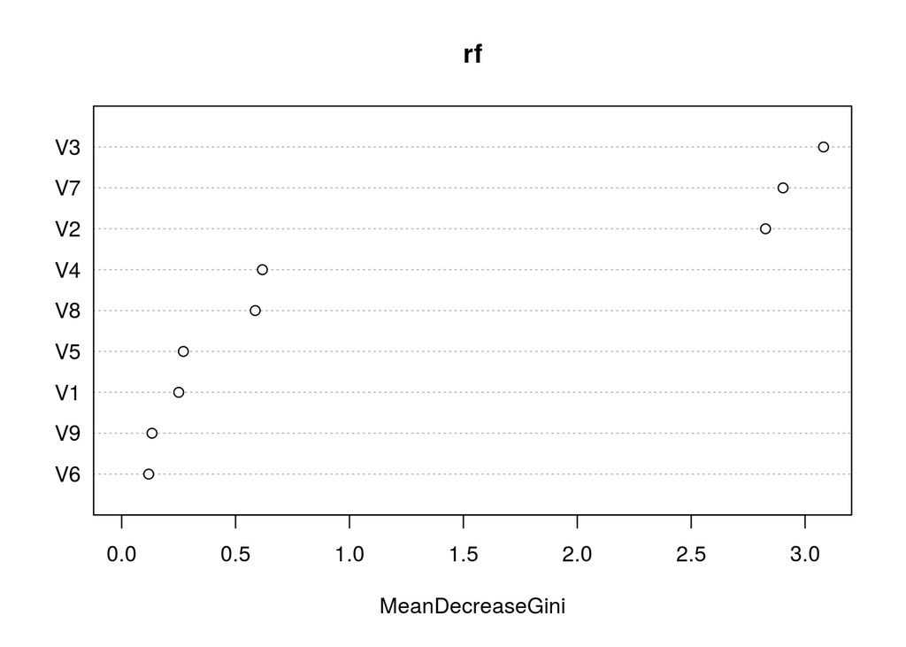

```r
varImpPlot(rf)
```

Możesz również przetestować różne liczby zmiennych losowanych przy podziale węzłów modyfikując atrybut mtry. Możesz też zmienić liczbę drzew za pomocą argumentu ntrees.

```r
rf1 <- randomForest(class~., data=biopsy, importance=TRUE, mtry=5, ntree=500)
rf1
```

```
##
## Call:
##  randomForest(formula = class ~ ., data = biopsy, importance = TRUE,      mtry = 5, ntree = 500)
##                Type of random forest: classification
##                      Number of trees: 500
## No. of variables tried at each split: 5
##
##         OOB estimate of  error rate: 2.93%
## Confusion matrix:
##           benign malignant class.error
## benign       432        12  0.02702703
## malignant      8       231  0.03347280
```

```r
computeOOBErrEst(rf1)
```

```
## [1] 0.02928258
```

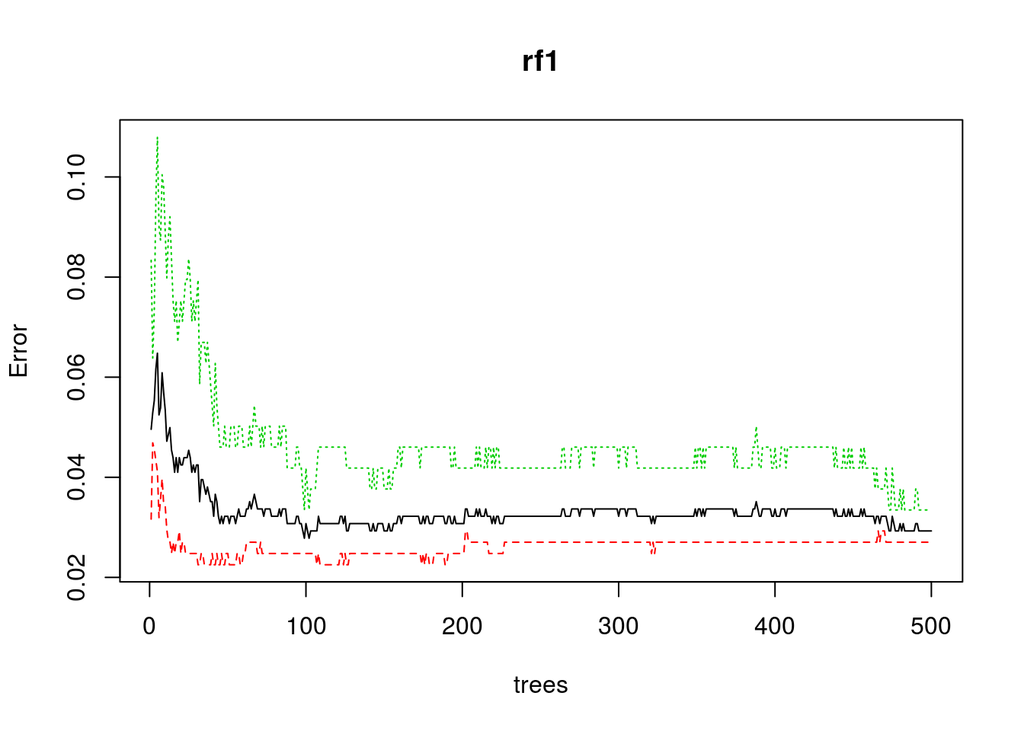

```r
plot(rf1)
```

- [X] Może być tu pomocna funkcja plot, która wywołana na utworzonym modelu przedstawi zależność błędu testowego od liczby użytych drzew.

W praktyce bierze się po prostu “dostatecznie dużo” drzew (na przykład 500) i nie przeprowadza dodatkowych analiz dotyczących ich optymalnej liczby, ponieważ ma to bardzo nieznaczny wpływ na błąd. Więcej informacji na ten temat można przeczytać tutaj.

Dla chętnych: Przeprowadź ręcznie walidację krzyżową i porównaj z estymatorem OOB.